# week_12_features_additive

## CMPINF 2100 Week 12

### Working with LINEAR MODELS with ADDITIVE features

We will GENERATE our own data for this example. This will again review the assumptions of the LINEAR MODEL!!!

We will fit the model using `statsmodels`. We will interpret the results via the COEFFICIENTS summaries. We will interpret the results through PREDICTIONS. And we will use specialized `statsmodels` graphics to get further insights into the behavior.

## Import Modules

```python
import numpy as np
import pandas as pd
import matplotlib.pyplot as plt

import seaborn as sns
```

```python
import statsmodels.formula.api as smf
```

## Linear Additive Features

We will work with 2 inputs but the ideas scale to many inputs.

To create our own data, we MUST specify the regression coefficients!!

```python
b0 = -0.25
b1 = 1.95
b2 = 0.2
```

## Make random input data

Randomly generate input values for this problem. Lets assume both inputs have STANDARD NORMAL DISTRIBUTIONS.

STANDARD NORMAL are Gaussians with MEAN 0 and STANDARD DEVIATION of 1.

```python
N = 35 ## number of observations
```

```python
rg = np.random.default_rng(2100)
```

Call the random number generate for 2 inputs.

```python
input_df = pd.DataFrame({"x1": rg.normal(loc=0, scale=1, size=N),
                         "x2": rg.normal(loc=0, scale=1, size=N)
})
```

```python
input_df.info()
```

```
<class 'pandas.core.frame.DataFrame'>
RangeIndex: 35 entries, 0 to 34
Data columns (total 2 columns):
 #   Column  Non-Null Count  Dtype
---  ------  --------------  -----
 0   x1      35 non-null     float64
 1   x2      35 non-null     float64
dtypes: float64(2)
memory usage: 688.0 bytes
```

```python
input_df.head()
```

|  | x1 | x2 |
| --- | --- | --- |
| 0 | 1.024252 | -0.650623 |
| 1 | -1.733671 | 0.993904 |
| 2 | -0.089294 | 0.251805 |
| 3 | -1.093748 | 1.356543 |
| 4 | 0.320995 | -0.145121 |

Calculate the TREND or AVERAGE OUTPUT assuming the LINEAR ADDITIVE FEATURES.

```python
df = input_df.copy()
```

```python
df["trend"] = b0 + b1*df.x1 + b2*df.x2
```

The OUTPUT is NORMALLY distributed around the TREND!!!

We will call ONE MORE Gaussian random number generator!!!

We need to set the RESIDUAL ERROR or REMAINING VARIATION AROUND THE TREND!!!

```python
my_sigma = 0.85
```

```python
df["y"] = rg.normal(loc=df.trend, scale=my_sigma, size=df.shape[0])
```

## Visualize the relationships between inputs and output

Start with the relationship between x1 and y.

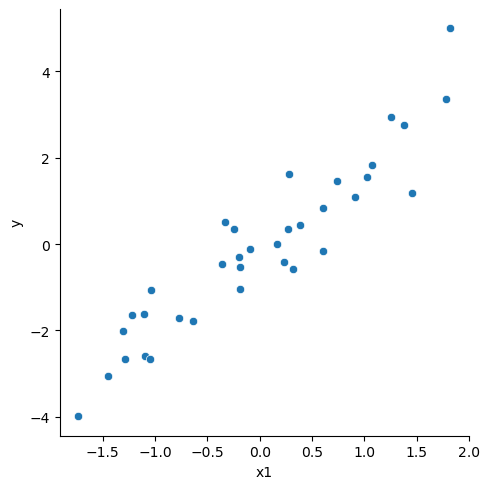

```python
sns.relplot(data=df, x="x1", y="y")

plt.show()
```

Lets now examine the relationship between x2 and y.

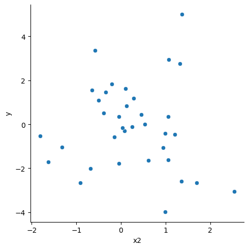

```python
sns.relplot(data=df, x="x2", y="y")

plt.show()
```

We can include LINEAR TREND LINES to help identify POSSIBLE trends between the OUTPUT and the INPUTS.

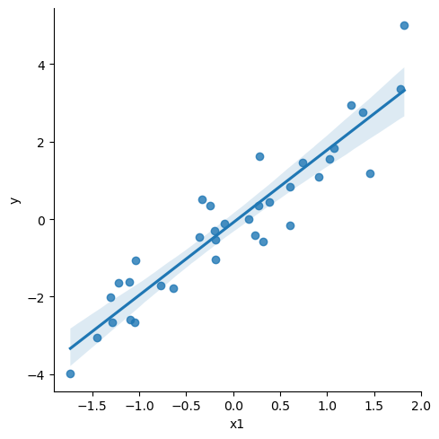

```python
sns.lmplot(data=df, x="x1", y="y")

plt.show()
```

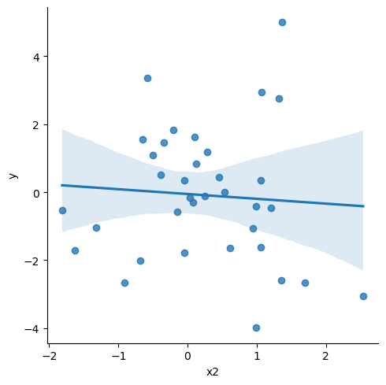

```python
sns.lmplot(data=df, x="x2", y="y")

plt.show()
```

## Fit linear models to confirm the visualizations

Fit a linear model with a LINEAR RELATIONSHIP between the TREND and x1 and BY ITSELF.

```python
fit_x1 = smf.ols(formula="y ~ x1", data=df).fit()
```

```python
fit_x1.summary()
```

OLS Regression Results

| Dep. Variable: | y | R-squared: | 0.873 |
| --- | --- | --- | --- |
| Model: | OLS | Adj. R-squared: | 0.869 |
| Method: | Least Squares | F-statistic: | 226.4 |
| Date: | Fri, 15 Nov 2024 | Prob (F-statistic): | 2.47e-16 |
| Time: | 00:16:20 | Log-Likelihood: | -36.764 |
| No. Observations: | 35 | AIC: | 77.53 |
| Df Residuals: | 33 | BIC: | 80.64 |
| Df Model: | 1 |  |  |
| Covariance Type: | nonrobust |  |  |

|  | coef | std err | t | P>\|t\| | [0.025 | 0.975] |
| --- | --- | --- | --- | --- | --- | --- |
| Intercept | -0.0909 | 0.120 | -0.755 | 0.456 | -0.336 | 0.154 |
| x1 | 1.8711 | 0.124 | 15.047 | 0.000 | 1.618 | 2.124 |

| Omnibus: | 0.685 | Durbin-Watson: | 2.313 |
| --- | --- | --- | --- |
| Prob(Omnibus): | 0.710 | Jarque-Bera (JB): | 0.475 |
| Skew: | 0.279 | Prob(JB): | 0.788 |
| Kurtosis: | 2.882 | Cond. No. | 1.03 |

Notes:  
[1] Standard Errors assume that the covariance matrix of the errors is correctly specified.

Fit a linear model between the TREND and x2 by ITSELF.

```python
fit_x2 = smf.ols(formula="y ~ x2", data=df).fit()
```

```python
fit_x2.summary()
```

OLS Regression Results

| Dep. Variable: | y | R-squared: | 0.005 |
| --- | --- | --- | --- |
| Model: | OLS | Adj. R-squared: | -0.025 |
| Method: | Least Squares | F-statistic: | 0.1585 |
| Date: | Fri, 15 Nov 2024 | Prob (F-statistic): | 0.693 |
| Time: | 00:17:50 | Log-Likelihood: | -72.764 |
| No. Observations: | 35 | AIC: | 149.5 |
| Df Residuals: | 33 | BIC: | 152.6 |
| Df Model: | 1 |  |  |
| Covariance Type: | nonrobust |  |  |

|  | coef | std err | t | P>\|t\| | [0.025 | 0.975] |
| --- | --- | --- | --- | --- | --- | --- |
| Intercept | -0.0554 | 0.348 | -0.159 | 0.875 | -0.764 | 0.653 |
| x2 | -0.1412 | 0.355 | -0.398 | 0.693 | -0.862 | 0.580 |

| Omnibus: | 1.809 | Durbin-Watson: | 1.769 |
| --- | --- | --- | --- |
| Prob(Omnibus): | 0.405 | Jarque-Bera (JB): | 1.152 |
| Skew: | 0.442 | Prob(JB): | 0.562 |
| Kurtosis: | 3.092 | Cond. No. | 1.30 |

Notes:  
[1] Standard Errors assume that the covariance matrix of the errors is correctly specified.

### Visualize the COEFFICIENT SUMMARIES

```python
def my_coefplot(mod, figsize_use=(10,4)):
    fig, ax = plt.subplots(figsize=figsize_use)

    ax.errorbar(y=mod.params.index,
               x=mod.params,
               xerr=2*mod.bse, fmt="o", color="k", ecolor="k", elinewidth=2, ms=10)

    ax.axvline(x=0, linestyle="--", linewidth=3.5, color="grey")

    ax.set_xlabel("coefficient value")

    plt.show()
```

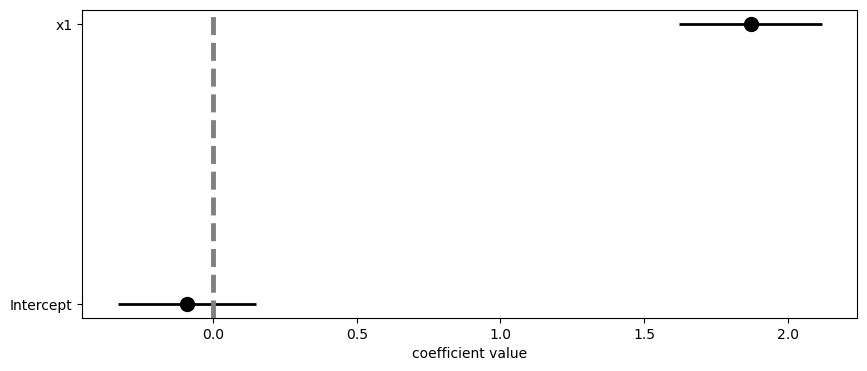

```python
my_coefplot(fit_x1)
```

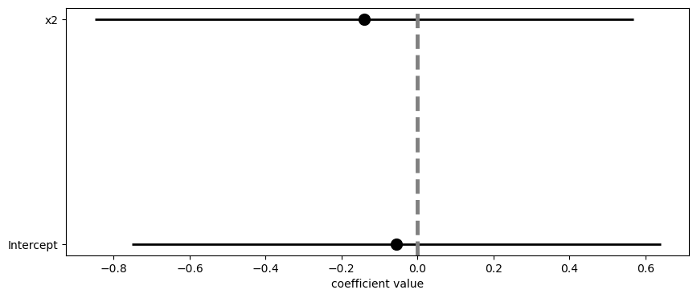

```python
my_coefplot(fit_x2)
```

### Linear additive features with BOTH inputs

```python
fit_x1x2_add = smf.ols(formula="y ~ x1 + x2", data=df).fit()
```

```python
fit_x1x2_add.summary()
```

OLS Regression Results

| Dep. Variable: | y | R-squared: | 0.874 |
| --- | --- | --- | --- |
| Model: | OLS | Adj. R-squared: | 0.866 |
| Method: | Least Squares | F-statistic: | 111.1 |
| Date: | Fri, 15 Nov 2024 | Prob (F-statistic): | 3.96e-15 |
| Time: | 01:14:07 | Log-Likelihood: | -36.577 |
| No. Observations: | 35 | AIC: | 79.15 |
| Df Residuals: | 32 | BIC: | 83.82 |
| Df Model: | 2 |  |  |
| Covariance Type: | nonrobust |  |  |

|  | coef | std err | t | P>\|t\| | [0.025 | 0.975] |
| --- | --- | --- | --- | --- | --- | --- |
| Intercept | -0.1099 | 0.126 | -0.873 | 0.389 | -0.366 | 0.146 |
| x1 | 1.8795 | 0.126 | 14.867 | 0.000 | 1.622 | 2.137 |
| x2 | 0.0756 | 0.129 | 0.587 | 0.562 | -0.187 | 0.338 |

| Omnibus: | 0.363 | Durbin-Watson: | 2.319 |
| --- | --- | --- | --- |
| Prob(Omnibus): | 0.834 | Jarque-Bera (JB): | 0.321 |
| Skew: | 0.210 | Prob(JB): | 0.852 |
| Kurtosis: | 2.791 | Cond. No. | 1.33 |

Notes:  
[1] Standard Errors assume that the covariance matrix of the errors is correctly specified.

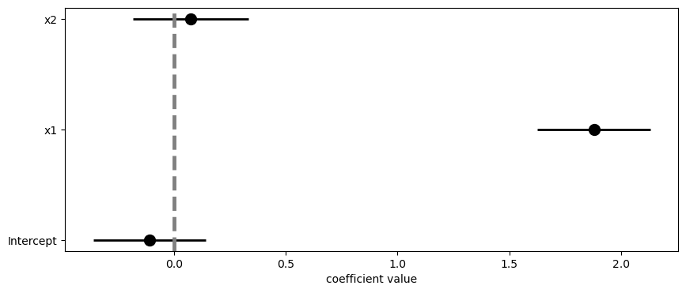

```python
my_coefplot(fit_x1x2_add)
```

## Predictions

Predictions involving MULTIPLE inputs REQUIRE DataFrames that have ALL inputs used to FIt the MODEL!!!

I like to VISUALIZE the RELATIONSHIP between the OUTPUT and the MOST IMPORTANT INPUT!!!

```python
np.abs(fit_x1x2_add.params).sort_values(ascending=False)
```

```
x1           1.879500
Intercept    0.109888
x2           0.075586
dtype: float64
```

Create a DataFrame with MANY values of x1 for a SINGLE value of x2.

```python
df_viz_1 = pd.DataFrame({"x1": np.linspace(df.x1.min()-0.02, df.x1.max()+.02, num=251)})
```

```python
df_viz_1
```

|  | x1 |
| --- | --- |
| 0 | -1.753671 |
| 1 | -1.739287 |
| 2 | -1.724903 |
| 3 | -1.710519 |
| 4 | -1.696135 |
| ... | ... |
| 246 | 1.784818 |
| 247 | 1.799202 |
| 248 | 1.813586 |
| 249 | 1.827970 |
| 250 | 1.842354 |

251 rows × 1 columns

```python
df_viz_1["x2"] = df.x2.mean()
```

```python
df_viz_1
```

|  | x1 | x2 |
| --- | --- | --- |
| 0 | -1.753671 | 0.251296 |
| 1 | -1.739287 | 0.251296 |
| 2 | -1.724903 | 0.251296 |
| 3 | -1.710519 | 0.251296 |
| 4 | -1.696135 | 0.251296 |
| ... | ... | ... |
| 246 | 1.784818 | 0.251296 |
| 247 | 1.799202 | 0.251296 |
| 248 | 1.813586 | 0.251296 |
| 249 | 1.827970 | 0.251296 |
| 250 | 1.842354 | 0.251296 |

251 rows × 2 columns

When we make predictions we WANT to include the TRENDS (average output), the UNCERTAINTY on the TREND (the CONFIDENCE INTERVAL), and the UNCERTAINTY of a SINGLE MEASUREMENT (the PREDICTION INTERVAL).

```python
predictions_1 = fit_x1x2_add.get_prediction(df_viz_1)
```

```python
pred_x1x2_add_summary = predictions_1.summary_frame()
```

```python
pred_x1x2_add_summary
```

|  | mean | mean_se | mean_ci_lower | mean_ci_upper | obs_ci_lower | obs_ci_upper |
| --- | --- | --- | --- | --- | --- | --- |
| 0 | -3.386918 | 0.252871 | -3.902000 | -2.871836 | -4.940541 | -1.833295 |
| 1 | -3.359883 | 0.251279 | -3.871721 | -2.848045 | -4.912434 | -1.807333 |
| 2 | -3.332848 | 0.249689 | -3.841448 | -2.824248 | -4.884335 | -1.781362 |
| 3 | -3.305814 | 0.248103 | -3.811182 | -2.800445 | -4.856243 | -1.755384 |
| 4 | -3.278779 | 0.246519 | -3.780922 | -2.776635 | -4.828160 | -1.729397 |
| ... | ... | ... | ... | ... | ... | ... |
| 246 | 3.263671 | 0.256327 | 2.741550 | 3.785793 | 1.707700 | 4.819642 |
| 247 | 3.290706 | 0.257929 | 2.765321 | 3.816091 | 1.733637 | 4.847775 |
| 248 | 3.317741 | 0.259534 | 2.789087 | 3.846395 | 1.759566 | 4.875916 |
| 249 | 3.344776 | 0.261142 | 2.812847 | 3.876705 | 1.785487 | 4.904065 |
| 250 | 3.371811 | 0.262753 | 2.836602 | 3.907020 | 1.811399 | 4.932223 |

251 rows × 6 columns

Visualize the predictions using ribbons for the UNCERTAINTY INTERVALS and LINES for the TREND!!!

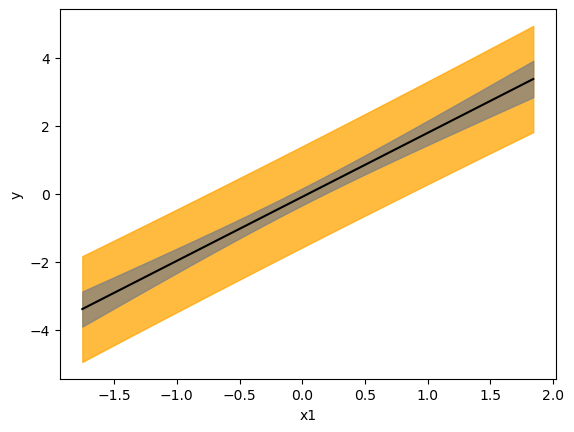

```python
fig, ax = plt.subplots()

## predictive interval
ax.fill_between(df_viz_1.x1,
               pred_x1x2_add_summary.obs_ci_lower,
               pred_x1x2_add_summary.obs_ci_upper,
               color="orange", edgecolor="orange", alpha=0.75)

## confidence interval
ax.fill_between(df_viz_1.x1,
               pred_x1x2_add_summary.mean_ci_lower,
               pred_x1x2_add_summary.mean_ci_upper,
               color="grey", edgecolor="grey", alpha=0.75)

## trend
ax.plot(df_viz_1.x1,
        pred_x1x2_add_summary["mean"], color="k", linewidth=1.5)

## set the labels
ax.set_xlabel("x1")
ax.set_ylabel("y")

## show the plots
plt.show()
```

Now if we want to EXAMINE the INFLUENCE of the OTHER INPUTS...then we need to allow the x2 INPUT to ALSO CHANGE!!!

The VISUALIZATION dataframe must therefore consider MULTIPLE **COMBINATIONS** of the continuous inputs!!!

We need to create a GRID of INPUT COMBINATIONS. Lets use a list comprehension to manage for us!!!

```python
input_grid = pd.DataFrame([(x1, x2) for x1 in np.linspace(df.x1.min(), df.x1.max(), num=101)
                                    for x2 in np.linspace(df.x2.min(), df.x2.max(), num=9)],
                          columns=["x1", "x2"])
```

```python
input_grid
```

|  | x1 | x2 |
| --- | --- | --- |
| 0 | -1.733671 | -1.813330 |
| 1 | -1.733671 | -1.269344 |
| 2 | -1.733671 | -0.725357 |
| 3 | -1.733671 | -0.181371 |
| 4 | -1.733671 | 0.362615 |
| ... | ... | ... |
| 904 | 1.822354 | 0.362615 |
| 905 | 1.822354 | 0.906601 |
| 906 | 1.822354 | 1.450587 |
| 907 | 1.822354 | 1.994573 |
| 908 | 1.822354 | 2.538560 |

909 rows × 2 columns

```python
input_grid.info()
```

```
<class 'pandas.core.frame.DataFrame'>
RangeIndex: 909 entries, 0 to 908
Data columns (total 2 columns):
 #   Column  Non-Null Count  Dtype
---  ------  --------------  -----
 0   x1      909 non-null    float64
 1   x2      909 non-null    float64
dtypes: float64(2)
memory usage: 14.3 KB
```

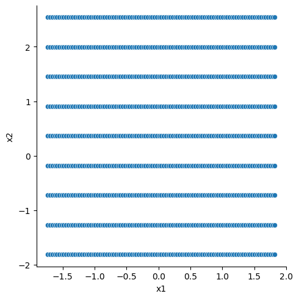

```python
sns.relplot(data=input_grid, x="x1", y="x2", kind="scatter")

plt.show()
```

Lets PREDICT using the input_grid BUT ONLY RETURN the PREDICTED TREND!! We will NOT return the UNCERTAINTY!!!

Use the .predict() method to RETURN the PREDICTED TREND!!!

```python
viz_grid = input_grid.copy()
```

```python
viz_grid["pred"] = fit_x1x2_add.predict(input_grid)
```

```python
viz_grid
```

|  | x1 | x2 | pred |
| --- | --- | --- | --- |
| 0 | -1.733671 | -1.813330 | -3.505384 |
| 1 | -1.733671 | -1.269344 | -3.464267 |
| 2 | -1.733671 | -0.725357 | -3.423149 |
| 3 | -1.733671 | -0.181371 | -3.382032 |
| 4 | -1.733671 | 0.362615 | -3.340914 |
| ... | ... | ... | ... |
| 904 | 1.822354 | 0.362615 | 3.342635 |
| 905 | 1.822354 | 0.906601 | 3.383753 |
| 906 | 1.822354 | 1.450587 | 3.424870 |
| 907 | 1.822354 | 1.994573 | 3.465988 |
| 908 | 1.822354 | 2.538560 | 3.507105 |

909 rows × 3 columns

Lets COLOR the PREDICTED TREND by each unique value of x2 to show the RELATIONSHIP of the TREND with respect to x1 for each unique value of x2!!!

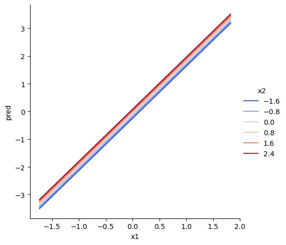

```python
sns.relplot(data=viz_grid,
            x="x1", y="pred",
            hue="x2",
            kind="line",
            estimator=None,
            units="x2",
           palette="coolwarm")

plt.show()
```

```python
fit_x1x2_add.summary()
```

OLS Regression Results

| Dep. Variable: | y | R-squared: | 0.874 |
| --- | --- | --- | --- |
| Model: | OLS | Adj. R-squared: | 0.866 |
| Method: | Least Squares | F-statistic: | 111.1 |
| Date: | Fri, 15 Nov 2024 | Prob (F-statistic): | 3.96e-15 |
| Time: | 01:59:38 | Log-Likelihood: | -36.577 |
| No. Observations: | 35 | AIC: | 79.15 |
| Df Residuals: | 32 | BIC: | 83.82 |
| Df Model: | 2 |  |  |
| Covariance Type: | nonrobust |  |  |

|  | coef | std err | t | P>\|t\| | [0.025 | 0.975] |
| --- | --- | --- | --- | --- | --- | --- |
| Intercept | -0.1099 | 0.126 | -0.873 | 0.389 | -0.366 | 0.146 |
| x1 | 1.8795 | 0.126 | 14.867 | 0.000 | 1.622 | 2.137 |
| x2 | 0.0756 | 0.129 | 0.587 | 0.562 | -0.187 | 0.338 |

| Omnibus: | 0.363 | Durbin-Watson: | 2.319 |
| --- | --- | --- | --- |
| Prob(Omnibus): | 0.834 | Jarque-Bera (JB): | 0.321 |
| Skew: | 0.210 | Prob(JB): | 0.852 |
| Kurtosis: | 2.791 | Cond. No. | 1.33 |

Notes:  
[1] Standard Errors assume that the covariance matrix of the errors is correctly specified.

## Statsmodels specialized graphics

`statsmodels` has specialized graphics to help you with visualizations of your linear models.

But there are a FEW THINGS you MUST remember when you use these functions!!

```python
import statsmodels.api as sm
```

Creating these specialized figures requires initializing the FIGURE and AXIS objects via matplotlib.

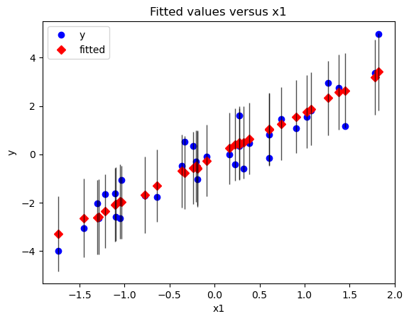

```python
fig, ax = plt.subplots()

sm.graphics.plot_fit(fit_x1x2_add, "x1", ax=ax)

plt.show()
```

Lets visualize the TRAINING SET FIT with respect to x2.

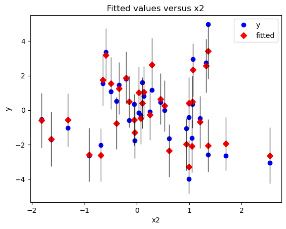

```python
fig, ax = plt.subplots()

sm.graphics.plot_fit(fit_x1x2_add, "x2", ax=ax)

plt.show()
```

We can examine the TRAINING SET PREDICTIONS or FITS and the RESIDUALS and the **PARTIAL REGRESSION PLOT** in one figure.

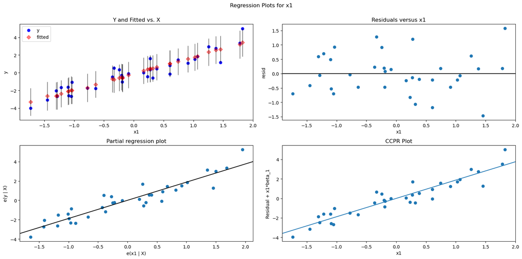

```python
fig = plt.figure(figsize=(16,8))

sm.graphics.plot_regress_exog(fit_x1x2_add, "x1", fig=fig)

plt.show()
```

Look at the partial regression plot for x2.

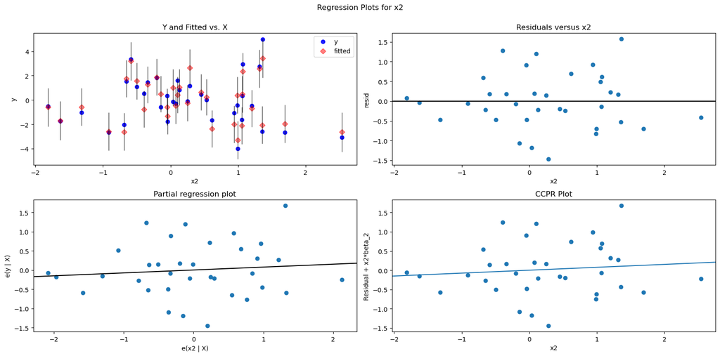

```python
fig = plt.figure(figsize=(16,8))

sm.graphics.plot_regress_exog(fit_x1x2_add, "x2", fig=fig)

plt.show()
```

```python
fit_x1x2_add.params
```

```
Intercept   -0.109888
x1           1.879500
x2           0.075586
dtype: float64
```

## Save our randomly generated data

```python
df.to_csv("linear_additive_example.csv", index=False)
```

```python
df
```

|  | x1 | x2 | trend | y |
| --- | --- | --- | --- | --- |
| 0 | 1.024252 | -0.650623 | 1.617167 | 1.547730 |
| 1 | -1.733671 | 0.993904 | -3.431878 | -3.988479 |
| 2 | -0.089294 | 0.251805 | -0.373762 | -0.107839 |
| 3 | -1.093748 | 1.356543 | -2.111500 | -2.594083 |
| 4 | 0.320995 | -0.145121 | 0.346917 | -0.583119 |
| 5 | -1.103206 | 1.054346 | -2.190382 | -1.612676 |
| 6 | -0.775994 | -1.629940 | -2.089175 | -1.722449 |
| 7 | -0.329677 | -0.391626 | -0.971196 | 0.520709 |
| 8 | -1.450625 | 2.538560 | -2.571008 | -3.060459 |
| 9 | 1.069088 | -0.201595 | 1.794402 | 1.818875 |
| 10 | -0.202412 | 0.074825 | -0.629738 | -0.293983 |
| 11 | -1.286002 | -0.912672 | -2.940238 | -2.656327 |
| 12 | -0.192696 | -1.316570 | -0.889071 | -1.047376 |
| 13 | -1.218619 | 0.616340 | -2.503039 | -1.654440 |
| 14 | 0.166197 | 0.530570 | 0.180198 | 0.001506 |
| 15 | 0.604931 | 0.034347 | 0.936486 | -0.150161 |
| 16 | 1.822354 | 1.362458 | 3.576082 | 4.991517 |
| 17 | -1.034873 | 0.940952 | -2.079811 | -1.064895 |
| 18 | 0.743416 | -0.338696 | 1.131923 | 1.448075 |
| 19 | 0.275892 | 0.101078 | 0.308205 | 1.618093 |
| 20 | 1.777869 | -0.587230 | 3.099399 | 3.368598 |
| 21 | 0.906866 | -0.498058 | 1.418777 | 1.088465 |
| 22 | -0.189357 | -1.813330 | -0.981912 | -0.523516 |
| 23 | 0.385830 | 0.449885 | 0.592346 | 0.449103 |
| 24 | -0.241629 | -0.047861 | -0.730749 | 0.345821 |
| 25 | 0.228725 | 0.987830 | 0.393579 | -0.427494 |
| 26 | 0.607804 | 0.128605 | 0.960938 | 0.825094 |
| 27 | -0.361445 | 1.201202 | -0.714577 | -0.471297 |
| 28 | 1.377761 | 1.317255 | 2.700084 | 2.748734 |
| 29 | 1.257839 | 1.072421 | 2.417271 | 2.949861 |
| 30 | 1.452826 | 0.285286 | 2.640067 | 1.177786 |
| 31 | -1.303433 | -0.684553 | -2.928605 | -2.022096 |
| 32 | 0.272273 | 1.063817 | 0.493695 | 0.337495 |
| 33 | -1.050327 | 1.693229 | -1.959491 | -2.653561 |
| 34 | -0.637415 | -0.042030 | -1.501364 | -1.783551 |